# 13 Teach : Shaders

## Objectives

- Learn about shaders using ThreeJS.

## Overview

> **Shaders**

> In computer graphics, a shader is a type of computer program originally used for shading in 3D scenes (the production of appropriate levels of light, darkness, and color in a rendered image). They now perform a variety of specialized functions in various fields within the category of computer graphics special effects, or else do video post-processing unrelated to shading, or even perform functions unrelated to graphics.

> Traditional shaders calculate rendering effects on graphics hardware with a high degree of flexibility. Most shaders are coded for (and run on) a graphics processing unit (GPU),[1] though this is not a strict requirement. Shading languages are used to program the GPU's rendering pipeline, which has mostly superseded the fixed-function pipeline of the past that only allowed for common geometry transforming and pixel-shading functions; with shaders, customized effects can be used. The position and color (hue, saturation, brightness, and contrast) of all pixels, vertices, and/or textures used to construct a final rendered image can be altered using algorithms defined in a shader, and can be modified by external variables or textures introduced by the computer program calling the shader.

> Shaders are used widely in cinema post-processing, computer-generated imagery, and video games to produce a range of effects. Beyond simple lighting models, more complex uses of shaders include: altering the hue, saturation, brightness (HSL/HSV) or contrast of an image; producing blur, light bloom, volumetric lighting, normal mapping (for depth effects), bokeh, cel shading, posterization, bump mapping, distortion, chroma keying (for so-called "bluescreen/greenscreen" effects), edge and motion detection, as well as psychedelic effects such as those seen in the demoscene.

> **Vertex shaders**

> Vertex shaders are the most established and common kind of 3D shader and are run once for each vertex given to the graphics processor. The purpose is to transform each vertex's 3D position in virtual space to the 2D coordinate at which it appears on the screen (as well as a depth value for the Z-buffer).[6] Vertex shaders can manipulate properties such as position, color and texture coordinates, but cannot create new vertices. The output of the vertex shader goes to the next stage in the pipeline, which is either a geometry shader if present, or the rasterizer. Vertex shaders can enable powerful control over the details of position, movement, lighting, and color in any scene involving 3D models.

> **Pixel shaders**

> Pixel shaders, also known as fragment shaders, compute color and other attributes of each "fragment": a unit of rendering work affecting at most a single output pixel. The simplest kinds of pixel shaders output one screen pixel as a color value; more complex shaders with multiple inputs/outputs are also possible. Pixel shaders range from simply always outputting the same color, to applying a lighting value, to doing bump mapping, shadows, specular highlights, translucency and other phenomena. They can alter the depth of the fragment (for Z-buffering), or output more than one color if multiple render targets are active. In 3D graphics, a pixel shader alone cannot produce some kinds of complex effects because it operates only on a single fragment, without knowledge of a scene's geometry (i.e. vertex data). However, pixel shaders do have knowledge of the screen coordinate being drawn, and can sample the screen and nearby pixels if the contents of the entire screen are passed as a texture to the shader. This technique can enable a wide variety of two-dimensional postprocessing effects such as blur, or edge detection/enhancement for cartoon/cel shaders. Pixel shaders may also be applied in intermediate stages to any two-dimensional images—sprites or textures—in the pipeline, whereas vertex shaders always require a 3D scene. For instance, a pixel shader is the only kind of shader that can act as a postprocessor or filter for a video stream after it has been rasterized.

-- [Shaders Wikipedia](https://en.wikipedia.org/wiki/Shader)

The thing to remember is that vertix shaders move vertices in a mesh and fragment shaders color the pixels in the mesh. By the time the fragement shader is used, any transformations to a mesh has been applied.

### Graphics Pipeline

As a review, the graphics pipeline has multiple stages in processing a scene graph. Here the vertex and fragment shaders can be programmed by a developer. These shaders programs run on the GPU. GPU's are highly parallel in running these shader programs.

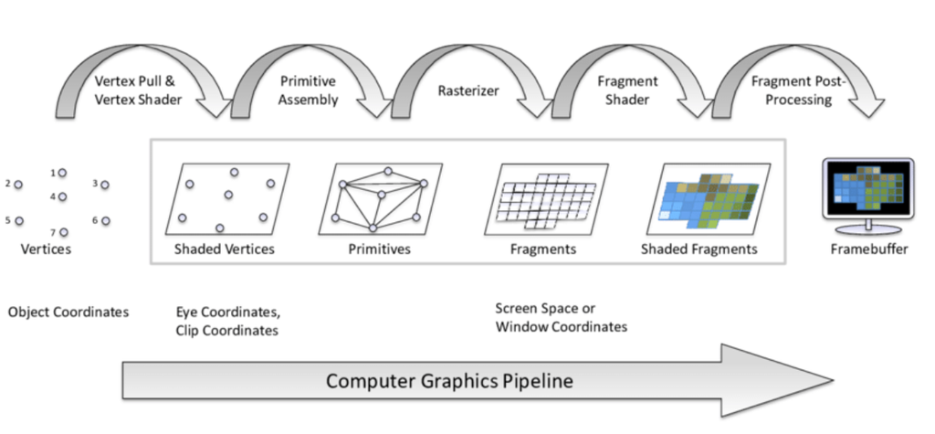

## ThreeJS shaders

ThreeJS has a material called ShaderMaterial that helps you write shaders for objects. Please read the [documention](https://threejs.org/docs/#api/en/materials/ShaderMaterial) on ShaderMaterial.

Here is an example of using ShaderMaterial:

```
const material = new THREE.ShaderMaterial( {

    uniforms: {

        time: { value: 1.0 },
        resolution: { value: new THREE.Vector2() }

    },

    vertexShader: document.getElementById( 'vertexShader' ).textContent,

    fragmentShader: document.getElementById( 'fragmentShader' ).textContent

} );
```

### Variables

There are three types of variables in shaders: uniforms, attributes, and varyings:

**Uniforms** are variables that have the same value for all vertices - lighting, fog, and shadow maps are examples of data that would be stored in uniforms. Uniforms can be accessed by both the vertex shader and the fragment shader.

**Attributes** are variables associated with each vertex---for instance, the vertex position, face normal, and vertex color are all examples of data that would be stored in attributes. Attributes can only be accessed within the vertex shader.

**Varyings** are variables that are passed from the vertex shader to the fragment shader. For each fragment, the value of each varying will be smoothly interpolated from the values of adjacent vertices.

### ThreeJS Built in Variables

-- [Built-in Shader Variables](https://threejs.org/docs/#api/en/renderers/webgl/WebGLProgram)

Here are the built-in variables ThreeJS will create and assign for your shaders.

```
// = object.matrixWorld
uniform mat4 modelMatrix;

// = camera.matrixWorldInverse * object.matrixWorld
uniform mat4 modelViewMatrix;

// = camera.projectionMatrix
uniform mat4 projectionMatrix;

// = camera.matrixWorldInverse
uniform mat4 viewMatrix;

// = inverse transpose of modelViewMatrix
uniform mat3 normalMatrix;

// = camera position in world space
uniform vec3 cameraPosition;
```

```
// default vertex attributes provided by Geometry and BufferGeometry
attribute vec3 position;
attribute vec3 normal;
attribute vec2 uv;
```

Note that you can therefore calculate the position of a vertex in the vertex shader by:

```
gl_Position = projectionMatrix * modelViewMatrix * vec4( position, 1.0 );
```

There Fragment shader has these built-in variables:

```
uniform mat4 viewMatrix;
uniform vec3 cameraPosition;
```

## ThreeJS "Hello World" Shader Example

The program below, there are two functions `vertexShader()` and `fragmentShader()` that return a string of the shader programs. `mesh2` create a shaderMaterial using those shader programs.

```
<html>
    <head>
        <title>My first Three.js app</title>
        <style>
            body { margin: 0; }
            canvas { width: 100%; height: 100% }
        </style>
</head>
<body>

    <div id="ThreeJS" style="position: absolute; left:0px; top:0px"></div>
    <script src="three.min.js"></script>
    <script src="OrbitControls.js"></script>

    <script>

        var scene, camera, renderer;
        var geometry, material, mesh1, mesh2;
        var rotationPL1 = 0;
        var rotationCamera = 0
        var light
        var uniforms = {}

        init();
        animate();

        function vertexShader() {
            return `
                void main() {
                    gl_Position = projectionMatrix * modelViewMatrix * vec4(position, 1.0);
                }
            `
        }

        function fragmentShader() {
            return `
                void main() {
                    gl_FragColor = vec4(
                        1.0,  // R
                        0.0,  // G
                        0.0,  // B
                        1.0); // A
                }
            `
        }

        function init() {

            // Create the main scene for the 3D drawing
            scene = new THREE.Scene();

            // Every scene needs a camera
            camera = new THREE.PerspectiveCamera(45, window.innerWidth / window.innerHeight, 1, 10000);

            camera.position.x = 0;
            camera.position.y = 50;
            camera.position.z = 150;

            camera.lookAt(new THREE.Vector3(0,0,0));

            geometry = new THREE.SphereGeometry( 10, 32, 32 );
            material = new THREE.MeshLambertMaterial( { color: 0xffffff, wireframe: false } );

            mesh1 = new THREE.Mesh( geometry, material );
            mesh1.position.set(-20, 15, 0);
            scene.add(mesh1);

            mesh2 = new THREE.Mesh(
                geometry,
                new THREE.ShaderMaterial({
                    fragmentShader: fragmentShader(),
                    vertexShader: vertexShader(),
                })
            );
            mesh2.position.set(20, 15, 0);
            scene.add(mesh2);


            const skyColor = 0xB1E1FF;  // light blue
            const groundColor = 0x000000;  // brownish orange
            const intensity = 1;
            const light = new THREE.HemisphereLight(skyColor, groundColor, intensity);
            scene.add(light);

            object = new THREE.AxisHelper( 50 );
            object.position.set( 0, 0, 0 );
            scene.add( object );

            const gridHelper = new THREE.GridHelper( 400, 100, 0x0000ff, 0x808080 );
            scene.add( gridHelper );


            // the renderer renders the scene using the objects, lights and camera
            renderer = new THREE.WebGLRenderer();
            renderer.setSize( window.innerWidth, window.innerHeight );

            controls = new THREE.OrbitControls( camera, renderer.domElement );

            // Attach the threeJS renderer to the HTML page
            document.body.appendChild( renderer.domElement );

        }

        // This is the game/animation loop
        // This is called ~60 times a second
        function animate() {

            requestAnimationFrame( animate );

            // Move anything you what
            rotationCamera -= 0.005;
            camera.position.y = 50;
            camera.position.x = Math.sin(rotationCamera) * 75;
            camera.position.z = Math.cos(rotationCamera) * 75;

            controls.update();

            renderer.render( scene, camera );
        }

</script>

</body>
</html>
```

Output screen:

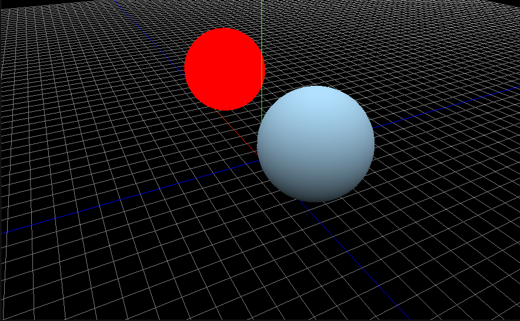

### Videos to Watch

- [Tutorial on Shaders in ThreeJS](https://www.youtube.com/watch?v=C8Cuwq1eqDw)